# Homework 10 - Final Exam

INFS 691

Rose Dunderdale

carSeats69NA.csv contains data about the sales of carseats. In this data set, a single observation represents a location where carseats are sold.  
In particular the data set consists of the following variables:

sales : Unit sales (in thousands) at each location compPrice : Price charged by competitor at each location income : Community income level (in thousands of dollars) advertising : Local advertising budget for company at each location (in thousands of dollars) population : Population size in region (in thousands) price-Price : Company charges for car seats at each site shelveLoc : A factor with levels Bad, Good and Medium indicating the quality of the shelving location for the car seats at each site age : Average age of the local population education : Education level at each location location : A factor with levels Urban and Rural to indicate whether the store is in an urban or rural location country : A factor with levels USA and Other to indicate whether the store is in the USA or not

### INITIAL WORK

0. Do the following:
1. Download the following files: carSeats691NA.csv  
   plots SV.docx  
   courses.csv  
   echo691.csv
2. Read the data set in “carSeats691NA.csv” and assign it to the object “seat”.

```r
seat <- read.csv("carSeats691NA.csv")
```

#### PLOTS USING ggplot2

Create the graphs using “ggplot2” package (The visuals for the plots are given in the “plots.docx” file)

1. Display the scatterplot of sales vs price with a linear line, no confidence interval for each shelveLoc level separately.  
   Use different colors for the plots for each shelveLoc level. (See “plots SV.docx” file for the display of the plot).

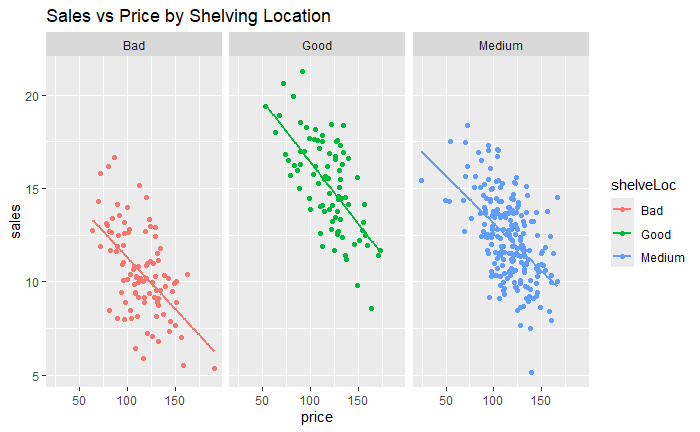

```r
library(ggplot2)
ggplot(seat, aes(x = price, y = sales, color = shelveLoc)) +
  geom_point() +
  geom_smooth(method = "lm", se = FALSE) +
  facet_wrap(~shelveLoc) +
  labs(title = "Sales vs Price by Shelving Location")
```

#### DATA MANIPULATION by built-in FUNCTIONS in R

#### “for” LOOOPS and “if” STATEMENTS as needed.

Anne R has prepared an Excel table containing information about the courses she has taken or registered.

She has saved this Excel file as a CSV (comma delimited) file named as “courses.csv”. Some scores listed are the expected scores.

2. Read this csv file into R, assign it to the object “course”, and display observations in “course” data frame.

```r
course <- read.csv("courses.csv")
course
```

| prefix | number | registered | score |
| --- | --- | --- | --- |
| ISSCM | 491 | 5-May-20 | 83 |
| INFS | 691 | 2-Jan-21 | 94 |
| BSAD | 443 | 15-Jul-20 | 99 |
| INFS | 592 | 21-Jan-21 | 75 |

3. Display the structure of the “course” data frame.

```r
str(course)
```

```
'data.frame':   4 obs. of  4 variables:
 $ prefix    : chr  "ISSCM" "INFS" "BSAD" "INFS"
 $ number    : int  491 691 443 592
 $ registered: chr  "5-May-20" "2-Jan-21" "15-Jul-20" "21-Jan-21"
 $ score     : int  83 94 99 75
```

4. What is the data type of Registered variable?  
   **Answer**: It is a character data type.

(5a) Change the values in Registered column to date objects. You need to use the “lubridate” package.

```r
# install.packages("lubridate")
library(lubridate)
course$registered <- mdy(course$registered)
```

(5b) Display the structure of the “course” again to see if the values in Registered column are changed to date objects.

```r
str(course)
```

```
'data.frame':   4 obs. of  4 variables:
 $ prefix    : chr  "ISSCM" "INFS" "BSAD" "INFS"
 $ number    : int  491 691 443 592
 $ registered: Date, format: NA NA NA NA
 $ score     : int  83 94 99 75
```

6. Display the list of the courses Anne registered before 2021-01-02. Need to write your code that will select the courses registered before 2021-01-02 so that this statement will work even if she has listed 14 courses in the data frame. course[c(1,3),] or course[-c(2,4),] are not acceptable.

```r
course[course$registered < as.Date("2021-01-02"), ]
```

|  | prefix | number | registered | score |
| --- | --- | --- | --- | --- |
| NA | NA | NA |  | NA |
| NA.1 | NA | NA |  | NA |
| NA.2 | NA | NA |  | NA |
| NA.3 | NA | NA |  | NA |

7. Create a vector “grade” that contains the letter grades assigned according to the following grade scale for the scores: score grade 93 and higher A 80 and under 93 B 70 and under 80 C less than 70 D

```r
grade <- ifelse(course$score >= 93, "A",
         ifelse(course$score >= 80, "B",
         ifelse(course$score >= 70, "C", "D")))
```

8. Add “grade” vector as a new column to the “course” data frame.

```r
course$grade <- grade
course
```

| prefix | number | registered | score | grade |
| --- | --- | --- | --- | --- |
| ISSCM | 491 |  | 83 | B |
| INFS | 691 |  | 94 | A |
| BSAD | 443 |  | 99 | A |
| INFS | 592 |  | 75 | C |

9. Using the “for” loop and “if” statement, count the number of “A” and “B” grades. The R code table(course$grade) gives the answer, but this statement is not acceptable.

Present the result/output showing the number of grades “A” and “B”.

```r
countA <- 0
countB <- 0
for (g in course$grade) {
  if (g == "A") {
    countA <- countA + 1
  } else if (g == "B") {
    countB <- countB + 1
  }
}
cat("Number of A grades:", countA, "\n")
```

```
Number of A grades: 2
```

```r
cat("Number of B grades:", countB, "\n")
```

```
Number of B grades: 1
```

#### DATA MANIPULATION by dplyr package

Complete the following data manipulation tasks using the “dplyr” package on carSeats69NA.csv data. You have already read this data as seat <- read.csv(“carSeats691NA.csv”) during the initial work. The R codes in this part should use the pipeline operator %>%.

10. Load the dplyr library functions

```r
library(dplyr)
```

11. Select sales, price, compPrice, and shelveLoc for observations with shelveLoc “Good” and country “USA” and display the result.

```r
seat %>%
  filter(shelveLoc == "Good", country == "USA") %>%
  select(sales, price, compPrice, shelveLoc)
```

| sales | price | compPrice | shelveLoc |
| --- | --- | --- | --- |
| 17.57 | 107 | 132 | Good |
| 17.85 | 112 | 123 | Good |
| 16.82 | 74 | 113 | Good |
| 17.53 | 112 | 142 | Good |
| 17.66 | 99 | 148 | Good |
| 17.29 | 131 | 147 | Good |
| 14.10 | 112 | 128 | Good |
| 13.21 | 123 | 127 | Good |
| 16.85 | 120 | 136 | Good |
| 14.43 | 129 | 115 | Good |

[output cut: 51 more lines]

12. Create a new variable revenue = sales * price and **add** it as a new column to the “seat” data frame.

```r
seat <- seat %>%
  mutate(revenue = sales * price)
```

13. Display the first 6 rows of the “seat” data frame and check to see if the new variable/vector “revenue” is added to the “seat” data frame. If it is not added, then correct your answer in Question 12 so that the new column “revenue” will be added as the last column.  
    Note: If “revenue” is displayed when you executed your code in question 12,it does not necessarily mean that the “revenue” column is added. If it were added, it would have been displayed in Question 13.

```r
head(seat)
```

|  | sales | price | compPrice | income | advertising | population | age | shelveLoc | location | country | revenue |
| --- | --- | --- | --- | --- | --- | --- | --- | --- | --- | --- | --- |
| 1 | 17.57 | 107 | 132 | 102 | 20 | 459 | 49 | Good | Urban | USA | 1879.99 |
| 2 | 12.99 | 99 | 127 | 59 | 4 | 339 | 65 | Medium | Urban | Other | 1286.01 |
| 3 | 16.19 | 72 | 98 | 104 | 23 | 404 | 27 | Medium | Rural | Other | 1165.68 |
| 4 | 9.11 | 106 | 113 | 69 | 11 | 94 | 76 | Medium | Rural | USA | 965.66 |
| 5 | 11.97 | 129 | 127 | 45 | 19 | 459 | 57 | Medium | Rural | USA | 1544.13 |
| 6 | 17.85 | 112 | 123 | 37 | 15 | 348 | 28 | Good | Urban | USA | 1999.20 |

14. For each shelveLoc, display the minimum sales (minS), maximum sales (maxS), mean sales (meanS) and also display a new column diffM=maxS-minS.

```r
seat %>%
  group_by(shelveLoc) %>%
  summarise(
    minS = min(sales, na.rm = TRUE),
    maxS = max(sales, na.rm = TRUE),
    meanS = mean(sales, na.rm = TRUE),
    diffM = max(sales, na.rm = TRUE) - min(sales, na.rm = TRUE)
  )
```

| shelveLoc | minS | maxS | meanS | diffM |
| --- | --- | --- | --- | --- |
| Bad | 5.37 | 16.67 | 10.52292 | 11.30 |
| Good | 8.58 | 21.27 | 15.21400 | 12.69 |
| Medium | 5.16 | 18.36 | 12.34091 | 13.20 |

#### FUNCTIONS

In this part, you will write functions to run on a vector. You will run your functions on the following vector: vec <- c(3, 9, 4, 5, 7, NA, 8, 5)

14. Execute the code chunk below to create the vector “vec”.

```r
vec <- c(3, 9, 4, 5, 7, NA, 8, 5)
```

15. Write a function that will determine if the number is less than 5, more than 5, or equal to 5. - Name the function as “moreLessEq” to return “LESS”, “MORE”, or “EQUAL” - Run this function on vector “vec” to see the result.

```r
moreLessEq <- function(x) {
  if (is.na(x)) return(NA)
  if (x < 5) return("LESS")
  else if (x > 5) return("MORE")
  else return("EQUAL")
}
sapply(vec, moreLessEq)
```

```
[1] "LESS"  "MORE"  "LESS"  "EQUAL" "MORE"  NA      "MORE"  "EQUAL"
```

16. Write a function that will count the number of even values in a vector. - Name the function as “countEven” to return the count of even numbers in the vector.  
    - Run this function on vector “vec” to display the result.

```r
countEven <- function(v) {
  sum(!is.na(v) & v %% 2 == 0)
}
countEven(vec)
```

```
[1] 2
```

17. Write a function “mySummary” that  
    - calculates the following three summary values for a vector:  
    count, mean, and standard deviation. Your function should consider the missing values (NA) in the vector.

```r
mySummary <- function(v) {
  c(
    count = sum(!is.na(v)),
    mean = mean(v, na.rm = TRUE),
    sd = sd(v, na.rm = TRUE)
  )
}
```

18. Run this function “mySummary” on vector “vec” to display the result.

```r
mySummary(vec)
```

```
   count     mean       sd
7.000000 5.857143 2.193063
```

#### apply() function

19. Use the apply() function to obtain the median of the values for each column (variable) in the “seat” data frame. Make sure that the medians are calculated for each numerical column.

```r
apply(seat[sapply(seat, is.numeric)], 2, median, na.rm = TRUE)
```

```
      sales       price   compPrice      income advertising  population         age     revenue
     12.495     117.000     125.000      69.000       9.000     271.000      54.000    1390.500
```

20. Use the apply() function and the function “mySummary” to display the three summary values for each numerical column (variable) in “seat” data frame.  
    Note: The mean and standard deviation cannot be calculated for the categorical variables (factor data types).

```r
apply(seat[sapply(seat, is.numeric)], 2, mySummary)
```

```
           sales     price compPrice    income advertising population       age  revenue
count 400.000000 400.00000 400.00000 400.00000  400.000000   400.0000 399.00000  400.000
mean   12.515125 115.62250 124.94000  68.77000    9.407500   264.6050  53.26566 1418.653
sd      2.799006  23.42117  15.31839  27.89637    5.514751   147.3024  16.16854  337.342
```

### ADVANCED REGRESSION

You will be using the data set stored in carSeats6NA.csv file for the regression model in this part. You have already read this data earlier during the initial work as seat <- read.csv(“carSeats691NA.csv”).

After comparing the performances of the regression models, you have preferred to use the following log-log regression model to predict the sales.

log(Y) = log(X1) + log(X2) + log(X3) + log(X4), where Y = sales, X1=price, X2=compPrice, X3=income, and X4=advertising

21. Run the log-log regression model (M4) and display the summary regression output.

```r
M4 <- lm(log(sales) ~ log(price) + log(compPrice) + log(income) + log(advertising), data = seat)
summary(M4)
```

```
Call:
lm(formula = log(sales) ~ log(price) + log(compPrice) + log(income) +
    log(advertising), data = seat)

Residuals:
     Min       1Q   Median       3Q      Max
-0.60722 -0.11032  0.00344  0.10428  0.48888

Coefficients:
                 Estimate Std. Error t value Pr(>|t|)
(Intercept)       0.96342    0.35217   2.736  0.00651 **
log(price)       -0.66674    0.04885 -13.648  < 2e-16 ***
log(compPrice)    0.88038    0.08676  10.148  < 2e-16 ***
log(income)       0.05756    0.01886   3.052  0.00242 **
log(advertising)  0.10243    0.01242   8.249  2.4e-15 ***
---
Signif. codes:  0 ‘***’ 0.001 ‘**’ 0.01 ‘*’ 0.05 ‘.’ 0.1 ‘ ’ 1

Residual standard error: 0.1746 on 395 degrees of freedom
Multiple R-squared:  0.4421,    Adjusted R-squared:  0.4364
F-statistic: 78.24 on 4 and 395 DF,  p-value: < 2.2e-16
```

22. What is the (log) regression equation? **Answer:** log(sales)=0.96342−0.66674⋅log(price)+0.88038⋅log(compPrice)+0.05756⋅log(income)+0.10243⋅log(advertising)
23. What is the coefficient of the “price” variable equal to in this log-log regression model? What does this coefficient indicate (tell)?  
    **Answer:**  
    Coefficient of log(price) = -0.66674. In a log-log regression, the coefficients represent elasticities - that is, the percentage change in the dependent variable (in this case, sales) for a 1% change in the independent variable.

Thus, a 1% increase in price is associated with approximately a 0.67% decrease in sales, holding all other variables constant.The negative relationship makes sense: as the price increases, fewer people are likely to buy the product, leading to lower sales.

24. What is the R squared value for this model? What does this R squared value indicate? **Answer:**  
    The R-squared for this model is 0.4421. Indicating, that approximatly of 44.21% of the variability in the log of sales can be explained by the log of price, log of competitor’s price, log of income, and log of advertising.

**This siggests a moderate level of explanatory power, it also means that**

55.79% of the variation in sales is due to other factors not included in the model.

25. Calculate 95% confidence interval estimate for the mean car seat sale of all car seats with the following values:  
    price=116, compPrice=125, income=70, advertising=10

```r
newdata <- data.frame(price = 116, compPrice = 125, income = 70, advertising = 10)
log_preds <- predict(M4, newdata = newdata, interval = "confidence")
exp(log_preds)
```

```
       fit      lwr      upr
1 12.49305 12.25719 12.73344
```

#### wordcloud USING TEXT MINING

Part of the reviews posted on Amazon by the users of “echo” is given in “echo691.csv” file.

Do the following:  
#### Note you do not need to do all text mining/sentiment analyses tasks.  
#### Do only the tasks asked in Questions 26a, 26b, and 27 to #### print the wordcloud only as asked in Question 28. Note:  
#### You do not need to create the objects “text2” and “words”.  
#### You do not need to built (create) the TermDocumentMatrix (tdm)

26. Read the text reviews from “echo691.txt” file.

```r
reviews <- readLines("echo691.txt")
```

(27a) Create the corpus.

```r
# install.packages("tm")
library(tm)
corpus <- Corpus(VectorSource(reviews))
```

(27b) Clean the corpus.  
Do not print out the corpus “inspect(corpus)” after each cleaning process.  
It will create too many pages.  
To observe the output, if you print out the result (ouput) after each cleaning operation, delete (x out) these outputs before you create the html file.

```r
corpus <- tm_map(corpus, content_transformer(tolower))
corpus <- tm_map(corpus, removePunctuation)
corpus <- tm_map(corpus, removeNumbers)
corpus <- tm_map(corpus, removeWords, stopwords("english"))
corpus <- tm_map(corpus, stripWhitespace)
```

28. Display word frequencies using wordcloud.  
    Use the following options in wordcloud:

set.seed(123)  
wordcloud(corpus,  
max.words=150,  
min.freq=1,  
random.order=F,  
color=rainbow(3),  
scale=c(4.0,0.1),  
rot.per=0.20)

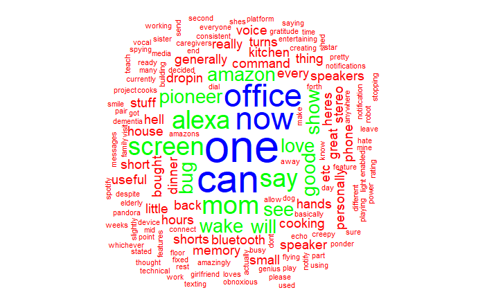

```r
# install.packages("wordcloud")
library(wordcloud)
set.seed(123)
wordcloud(corpus,
          max.words = 150,
          min.freq = 1,
          random.order = FALSE,
          colors = rainbow(3),
          scale = c(4.0, 0.1),
          rot.per = 0.20)
```

#### SIMULATION

One of the products manufactured by the National View Company is wireless security camera (WSC).

The variable labor cost per unit is uniformly distributed between $4 and $6.

Material cost per unit has a triangle distribution between $3 to $6 with the most likely price of $5.

Fixed costs for the wireless security camera are $3,000 per month.

The selling price for the wireless security camera is uniformly distributed between $25 and $30.

The company estimates that monthly demand for the wireless security camera depends on the market conditions in that month. Based on historical market research, the market has an equal probability of being either “High” or “Low” in any given month.

If the market condition is “high”, the monthly demand is normally distributed with a mean of 400 and a standard deviation of 10 units.  
If the market condition is “Low”, the monthly demand is normally distributed with a mean of 300 and a standard deviation of 5 units.

##Task  
Simulate 3000 trials to determine the monthly profits. Use set.seed(1) to initialize the random numbers before generating the values for the uncertain variables in the problem.

30. Simulation of 3000 trials to determine the profits.  
    Write the necessary R code to simulate this problem for 3,000 months.

```r
set.seed(1)

# number of trials
n <- 3000

#market conditions: "High" or "Low"
market_condition <- sample(c("High", "Low"), size = n, replace = TRUE)

# Demand based on market condition
demand <- ifelse(market_condition == "High",
                 rnorm(n, mean = 400, sd = 10),
                 rnorm(n, mean = 300, sd = 5))

# labor cost: unform between 4 & 6
labor_cost <- runif(n, min = 4, max = 6)

# Material cost: Triangle distribution between 3 and 6 with mode 5
# install.packages("triangle")
library(triangle)
material_cost <- rtriangle(n, a = 3, b = 6, c = 5)

# Selling price: Uniform between 25 and 30
price <- runif(n, min = 25, max = 30)

# Fixed cost
fixed_cost <- 3000

# Total cost and revenue
total_cost <- fixed_cost + demand * (labor_cost + material_cost)
revenue <- demand * price

# Monthly profit
profit <- revenue - total_cost
```

Based on your simulation results, answer the following questions (30a, 30b, 30c, 30d, and 30(e) outlined below.

30(a) Print the first 10 monthly profit values.

```r
head(profit, 10)
```

```
 [1] 5395.693 2334.895 3892.777 3116.646 2148.257 4797.795 4099.458 3584.588 1826.125 2017.115
```

30(b) Determine the proportion of months in which the market condition is classified as “High” based on your simulation results.

```r
mean(market_condition == "High")
```

```
[1] 0.499
```

30(c) Display the histogram of monthly profits.

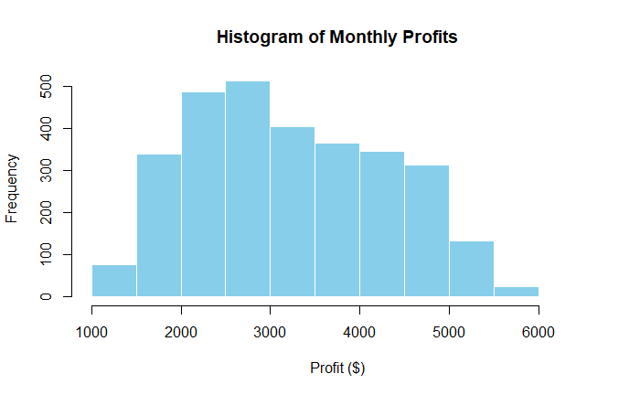

```r
hist(profit, main = "Histogram of Monthly Profits",
     xlab = "Profit ($)", col = "skyblue", border = "white")
```

30(d) Display the Histogram of Monthly Material Costs

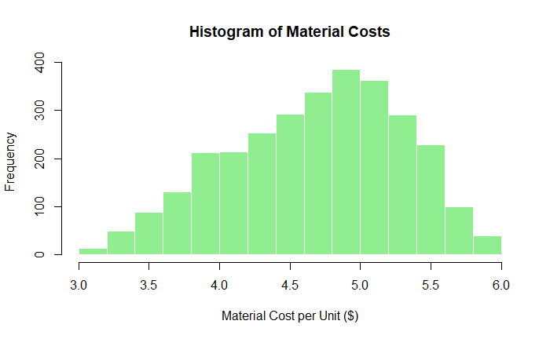

```r
hist(material_cost, main = "Histogram of Material Costs",
     xlab = "Material Cost per Unit ($)", col = "lightgreen", border = "white")
```

30(e) Use the “mySummary” function that created in Question 17 above to calculate the count, mean, and the standard deviation of the profits?

```r
mySummary(profit)
```

```
   count     mean       sd
3000.000 3225.183 1067.196
```

### CREATE THE HTML FILE.

31. At the end, before submitting your html file, do the following: Step 1.Starting from the first chunk code, execute each R chunk one by one (from 1st to the last in that order) Step 2. Save your file “Save As..” This will create the html file. Please check to make sure that your html file contains R codes, outputs (from the execution), and answers to the questions (if there is any)

Submit this html file as your homework 10 (final exam) on Sakai.